# Correlations and Regression Models - Logistic Regression Models Tutorial

Series on Statistics - 2024

Philipp Mildenberger Institute of Medical Biostatistics, Epidemiology and Informatics (IMBEI) pmildenb@uni-mainz.de

2024-03-28

[figure not shown]

# 1 Data Exploration

Welcome to the Logistic Regression Models tutorial. The next few tasks will guide you through the necessary steps for fitting and assessing Logistic Regression Models. For this tutorial you will start working on the famous “birthweight” data (*birthwt* from the MASS package) The example models will try to identify important risk factors for whether a newborn has a birthweight under 2.5 kg. You can find some background information about the birthweight dataset here: https://stat.ethz.ch/R-manual/R-patched/library/MASS/html/birthwt.html

We will treat these birthweight data as data from a retrospective study and your aim is an exploratory analysis: You try to identify variables that could predict whether a newborn has a low birthweight.

Start by exploring this dataset and first look at the first few rows of the R data frame. Then display the R format of all variables.

```r
# display first rows of the data frame
kable(head(birthwt))
```

|  | low | age | lwt | race | smoke | ptl | ht | ui | ftv | bwt |
| --- | --- | --- | --- | --- | --- | --- | --- | --- | --- | --- |
| 85 | 0 | 19 | 182 | 2 | 0 | 0 | 0 | 1 | 0 | 2523 |
| 86 | 0 | 33 | 155 | 3 | 0 | 0 | 0 | 0 | 3 | 2551 |
| 87 | 0 | 20 | 105 | 1 | 1 | 0 | 0 | 0 | 1 | 2557 |
| 88 | 0 | 21 | 108 | 1 | 1 | 0 | 0 | 1 | 2 | 2594 |
| 89 | 0 | 18 | 107 | 1 | 1 | 0 | 0 | 1 | 0 | 2600 |
| 91 | 0 | 21 | 124 | 3 | 0 | 0 | 0 | 0 | 0 | 2622 |

```r
# check the name and class of all variables
kable(data.frame(lapply(birthwt, class)))
```

| low | age | lwt | race | smoke | ptl | ht | ui | ftv | bwt |
| --- | --- | --- | --- | --- | --- | --- | --- | --- | --- |
| integer | integer | integer | integer | integer | integer | integer | integer | integer | integer |

Now that you got a first impression of the data, display the response variable (the low birthweight indicator) in a bar- or piechart.

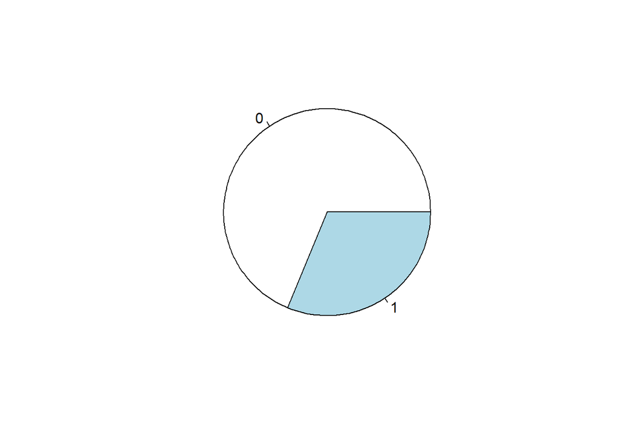

```r
# create a piechart
pie(table(birthwt$low))
```

Now explore the relationships between explanatory variables and the response in suitable plots or tables of the response and each of the explanatory variables. These could e.g. be: Cross-tables if the explanatory variable is categorical or grouped histograms or scatterplots if the explanatory variable is continuous.

This should usually be done for all pairs of the response and an explanatory variable. For simplicity here, chose one variable and create a plot or table of this variable and the birthweight indicator.

```r
# cross table of smoler status and the birthweight indicator
table(birthwt[, c("low", "smoke")])
```

```
##    smoke
## low  0  1
##   0 86 44
##   1 29 30
```

# 2 Model Estimation

After exploring potential important explanatory variables we can now fit the first model. This model should include one explanatory variable: The mother’s age (“age”).

The R-function *glm* is well suited for fitting Logistic Regression Models. This is the main function for fitting Generalized Linear Models, the broader category of statistical models that Logistic Regression belongs to. You can find this function’s documentation by typing *?glm* or here online: http://stat.ethz.ch/R-manual/R-devel/library/stats/html/glm.html

The type of Generalized Linear Model is defined in the “family” argument. This argument is used to specify two related properties of the model, the error distribution and the link function. You should use a binomial error distribution and the logit link if you want to fit a Logistic Regression Model.

Now fit the model with one explanatory variable and store it in an R object called *logistic.model.1*. Then display the estimated coefficients.

```r
# fit the first logistic regression model
logistic.model.1 <- glm(formula = low ~ age, family = binomial(link = "logit"), data = birthwt)


# display the estimated coefficients
summary(logistic.model.1)
```

```
##
## Call:
## glm(formula = low ~ age, family = binomial(link = "logit"), data = birthwt)
##
## Coefficients:
##             Estimate Std. Error z value Pr(>|z|)
## (Intercept)  0.38458    0.73212   0.525    0.599
## age         -0.05115    0.03151  -1.623    0.105
##
## (Dispersion parameter for binomial family taken to be 1)
##
##     Null deviance: 234.67  on 188  degrees of freedom
## Residual deviance: 231.91  on 187  degrees of freedom
## AIC: 235.91
##
## Number of Fisher Scoring iterations: 4
```

Now use the R funtion *glm* again to fit a second model. This model should use two additional explanatory variables, the mother’s smoking status during pregnancy and the number of previous premature labours.

Save this model in the R object *logistic.model.2* and display the model summary.

```r
# fit the second logistic regression model
logistic.model.2 <- glm(formula = low ~ age + smoke + as.factor(ptl),
                        family = binomial(link = "logit"), data = birthwt)


# display the estimated coefficients
summary(logistic.model.2)
```

```
##
## Call:
## glm(formula = low ~ age + smoke + as.factor(ptl), family = binomial(link = "logit"),
##     data = birthwt)
##
## Coefficients:
##                  Estimate Std. Error z value Pr(>|z|)
## (Intercept)       0.38423    0.80838   0.475   0.6346
## age              -0.07344    0.03514  -2.090   0.0366 *
## smoke             0.54828    0.34037   1.611   0.1072
## as.factor(ptl)1   1.85164    0.49795   3.719   0.0002 ***
## as.factor(ptl)2   0.51456    0.94643   0.544   0.5867
## as.factor(ptl)3 -13.66258  882.74342  -0.015   0.9877
## ---
## Signif. codes:  0 '***' 0.001 '**' 0.01 '*' 0.05 '.' 0.1 ' ' 1
##
## (Dispersion parameter for binomial family taken to be 1)
##
##     Null deviance: 234.67  on 188  degrees of freedom
## Residual deviance: 211.19  on 183  degrees of freedom
## AIC: 223.19
##
## Number of Fisher Scoring iterations: 13
```

```r
## How to interpret:
#
# First note that we should model the number of previous premature labours as a
# factor variable. That way, we get three beta estimates:
#  - comparison of women with one premature labour vs women without
#  - comparison of women with two premature labours vs women without
#  - comparison of women with three premature labours vs women without
#
# the last two have rather large standard errors, pointing at small subgroups.
# As a bonus, let us thus create a new model that only uses
# the information whether any previous premature labours have occurred.

logistic.model.2a <- glm(formula = low ~ age + smoke + (ptl>0),
                        family = binomial(link = "logit"), data = birthwt)
summary(logistic.model.2a)
```

```
##
## Call:
## glm(formula = low ~ age + smoke + (ptl > 0), family = binomial(link = "logit"),
##     data = birthwt)
##
## Coefficients:
##             Estimate Std. Error z value Pr(>|z|)
## (Intercept)  0.30351    0.79669   0.381 0.703236
## age         -0.06903    0.03448  -2.002 0.045281 *
## smoke        0.50849    0.33723   1.508 0.131594
## ptl > 0TRUE  1.50176    0.43687   3.438 0.000587 ***
## ---
## Signif. codes:  0 '***' 0.001 '**' 0.01 '*' 0.05 '.' 0.1 ' ' 1
##
## (Dispersion parameter for binomial family taken to be 1)
##
##     Null deviance: 234.67  on 188  degrees of freedom
## Residual deviance: 215.04  on 185  degrees of freedom
## AIC: 223.04
##
## Number of Fisher Scoring iterations: 4
```

# 3 Model Selection

The first and second models’ performances should now be compared. An appropriate measure of how well these models fit is Akaike’s Information Criterion (AIC). Logistic Regression models are estimated via the Maximum Likelihood Method and the AIC value of a model directly builts on its achieved likelihood value. **Lower AIC values are better**.

Now extract the AIC and compare the AIC values of both models. Which model would you prefer?

```r
# extract the AIC values from both models
data.frame(
  Model = c("age", "age + smoke + as.factor(ptl)", "age + smoke + (ptl>0)"),
  AIC = c(
  extractAIC(logistic.model.1)[2],
  extractAIC(logistic.model.2)[2],
  extractAIC(logistic.model.2a)[2]
  )
  )
```

```
##                          Model      AIC
## 1                          age 235.9120
## 2 age + smoke + as.factor(ptl) 223.1881
## 3        age + smoke + (ptl>0) 223.0399
```

```r
# compare using `add1`
add1(logistic.model.1,
     scope=as.formula("low~age+smoke+I(ptl>0)+as.factor(ptl)"),
     test="Chisq")
```

```
## Single term additions
##
## Model:
## low ~ age
##                Df Deviance    AIC     LRT  Pr(>Chi)
## <none>              231.91 235.91
## smoke           1   227.28 233.28  4.6357 0.0313140 *
## I(ptl > 0)      1   217.30 223.30 14.6140 0.0001319 ***
## as.factor(ptl)  3   213.77 223.77 18.1446 0.0004106 ***
## ---
## Signif. codes:  0 '***' 0.001 '**' 0.01 '*' 0.05 '.' 0.1 ' ' 1
```

```r
# or using the step function
step(logistic.model.1,
     scope=as.formula("low~age+smoke+I(ptl>0)+as.factor(ptl)"),
     direction="forward")
```

```
## Start:  AIC=235.91
## low ~ age
##
##                  Df Deviance    AIC
## + I(ptl > 0)      1   217.30 223.30
## + as.factor(ptl)  3   213.77 223.77
## + smoke           1   227.28 233.28
## <none>                231.91 235.91
##
## Step:  AIC=223.3
## low ~ age + I(ptl > 0)
##
##                  Df Deviance    AIC
## + smoke           1   215.04 223.04
## <none>                217.30 223.30
## + as.factor(ptl)  2   213.77 223.77
##
## Step:  AIC=223.04
## low ~ age + I(ptl > 0) + smoke
##
##                  Df Deviance    AIC
## <none>                215.04 223.04
## + as.factor(ptl)  2   211.19 223.19
```

```
##
## Call:  glm(formula = low ~ age + I(ptl > 0) + smoke, family = binomial(link = "logit"),
##     data = birthwt)
##
## Coefficients:
##    (Intercept)             age  I(ptl > 0)TRUE           smoke
##        0.30351        -0.06903         1.50176         0.50849
##
## Degrees of Freedom: 188 Total (i.e. Null);  185 Residual
## Null Deviance:       234.7
## Residual Deviance: 215   AIC: 223
```

# 4 Model Assessment

Although assessing whether a model’s assumptions are met is generally an important part in statistical modelling, there is no straightforward method for this in Logistic Regression. An interesting (and very general) approach is to simulate residuals from the fitted model and compare the actual residual to the simulated ones. (See https://cran.r-project.org/web/packages/DHARMa/vignettes/DHARMa.html)

If many data or a second dataset from the same study was available you could also use them to validate your model. This would mean fitting the model to one sample and using it to predict for another sample. Performance statistics based on the predictive power of your model could then be compared for both sample in order to assesss the model’s overall performance.

# 5 Model Interpretation

Now that you have chosen one model and made sure that its general structure is plausible, you can finally start interpreting the model. A Logistic Regression Model predicts probabilities of an event occuring. To visualise these predicted probabilites, extract them from the fitted model object and create a histogram of these probabilites. Then calculate the proportion of actually observed events (birthweights categorized as low) in the data. How does the histogram compare to this proportion?

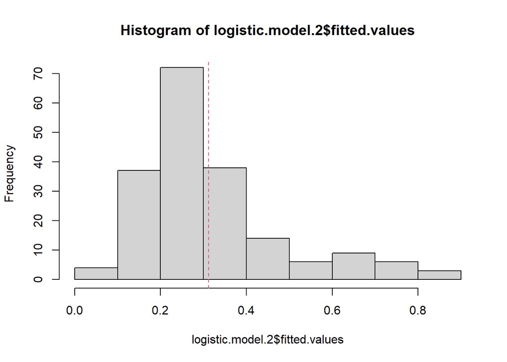

```r
hist(logistic.model.2$fitted.values)
abline(v = mean(birthwt$low), col = 2, lty = 2)
```

After examining the predicted probabilities, now examine the model’s estimated coefficients. On which scale are these?

```r
# get the coefficients from the model object
logistic.model.2$coefficients
```

```
##     (Intercept)             age           smoke as.factor(ptl)1 as.factor(ptl)2
##      0.38423122     -0.07344001      0.54828057      1.85164081      0.51456362
## as.factor(ptl)3
##    -13.66257929
```

After extracting the raw coefficients from the R model object, now apply the appropriate transformation in order to get the odds ratios for both coefficients. How are these interpreted?

```r
# calculate the odds ratios
exp(logistic.model.2$coefficients)
```

```
##     (Intercept)             age           smoke as.factor(ptl)1 as.factor(ptl)2
##    1.468485e+00    9.291919e-01    1.730275e+00    6.370263e+00    1.672908e+00
## as.factor(ptl)3
##    1.165245e-06
```

Although our model was fitted as part of an exploratory analysis and not in a confirmatory setting, we could still examine hypothesis test results but should be careful not to over-interpret them. First run an overall model fit hypothesis test, trying to reject the null hypothesis that all explanatory variable coefficients are equal to zero.

In order to run this test you first need to specify an additional model that only includes an intercept (Hint: *low ~ 1*). Call this model *logistic.model.0*. The likelihood ratio test that compares two models can then be run using the R function *anova* and the *test = “LRT”* option.

```r
# run a likelihood ratio test for overall model fit

# fit the null model
logistic.model.0 <- glm(formula = low ~ 1, family = binomial(link = "logit"), data = birthwt)

# run the test
anova(logistic.model.2, logistic.model.0, test = "LRT")
```

```
## Analysis of Deviance Table
##
## Model 1: low ~ age + smoke + as.factor(ptl)
## Model 2: low ~ 1
##   Resid. Df Resid. Dev Df Deviance  Pr(>Chi)
## 1       183     211.19
## 2       188     234.67 -5  -23.484 0.0002727 ***
## ---
## Signif. codes:  0 '***' 0.001 '**' 0.01 '*' 0.05 '.' 0.1 ' ' 1
```

Now that you have tested the overall null hypothesis that all explanatory variable coefficients are equal to zero, you can look at individual hypothesis tests for each coefficient. These tests are called Wald Tests and they try to reject the null hypothesis that an individual coefficient is equal to zero. A low p-value for a coefficient would support the hypothesis that this variable influences the reponse but would not necessarity say much about the magnitude of the effect or whether it is really a causal relationship.

Run Wald Tests for the three explanatory variable coefficients in our best model. Which of the explanatory variables appears to have a non-zero effect on the low birthweight indicator? Hint: Wald Tests for the coefficients can easily be computed from the fitted model object, via a summary of the model object.

```r
# results from a Wald tests
summary(logistic.model.2)
```

```
##
## Call:
## glm(formula = low ~ age + smoke + as.factor(ptl), family = binomial(link = "logit"),
##     data = birthwt)
##
## Coefficients:
##                  Estimate Std. Error z value Pr(>|z|)
## (Intercept)       0.38423    0.80838   0.475   0.6346
## age              -0.07344    0.03514  -2.090   0.0366 *
## smoke             0.54828    0.34037   1.611   0.1072
## as.factor(ptl)1   1.85164    0.49795   3.719   0.0002 ***
## as.factor(ptl)2   0.51456    0.94643   0.544   0.5867
## as.factor(ptl)3 -13.66258  882.74342  -0.015   0.9877
## ---
## Signif. codes:  0 '***' 0.001 '**' 0.01 '*' 0.05 '.' 0.1 ' ' 1
##
## (Dispersion parameter for binomial family taken to be 1)
##
##     Null deviance: 234.67  on 188  degrees of freedom
## Residual deviance: 211.19  on 183  degrees of freedom
## AIC: 223.19
##
## Number of Fisher Scoring iterations: 13
```

A better way of assessing the random variation in the coefficiant estimates - especially in an explanatory setting - is the use of confidence intervals. In Logistic Regression it is important to differentiate between the “raw” coefficient estimates (log odds rations) and odds ratios that can be easily computed from them. Confidence intervals should be computed for the scale of interpretation, so for odds ratios in this case.

Calculate 95% confidence intervals for the coefficients odds ratios. Hint: The log odds ratios for coefficients are stored in the model object. Confidence intervals for the log odds ratios can be calculated by using the R funtion *confint.default*.

```r
# coefficient odds ratios and their confidence intervals
kable(
  exp(cbind(
  "Odds ratio" = coef(logistic.model.2),
  confint.default(logistic.model.2, level = 0.95)
  )))
```

|  | Odds ratio | 2.5 % | 97.5 % |
| --- | --- | --- | --- |
| (Intercept) | 1.4684849 | 0.3011434 | 7.1608685 |
| age | 0.9291919 | 0.8673533 | 0.9954393 |
| smoke | 1.7302754 | 0.8879554 | 3.3716252 |
| as.factor(ptl)1 | 6.3702633 | 2.4004894 | 16.9049924 |
| as.factor(ptl)2 | 1.6729083 | 0.2617404 | 10.6923579 |
| as.factor(ptl)3 | 0.0000012 | 0.0000000 | Inf |

# 6 References

- Hosmer and Lemeshow (1989), “Applied Logistic Regression”
- Altman (1991), “Practical Statistics for Medical Research”